**Overfitting**

By Prof. Seungchul Lee  
http://iai.postech.ac.kr/  
Industrial AI Lab at POSTECH

Table of Contents

# 1. Regression with Polynomial Functions

- Nonlinear regression
- (= linear regression for non-linearly distributed data)

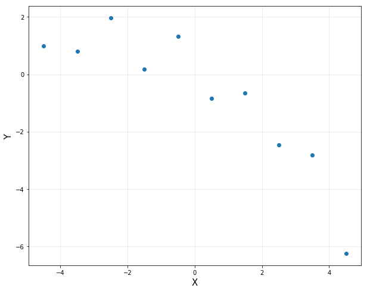

```python
import numpy as np
import matplotlib.pyplot as plt
%matplotlib inline

# 10 data points
n = 10
x = np.linspace(-4.5, 4.5, 10)
y = np.array([0.9819, 0.7973, 1.9737, 0.1838, 1.3180, -0.8361, -0.6591, -2.4701, -2.8122, -6.2512])

plt.figure(figsize=(10, 8))
plt.plot(x, y, 'o', label = 'Data')
plt.xlabel('X', fontsize = 15)
plt.ylabel('Y', fontsize = 15)
plt.grid(alpha = 0.3)
plt.show()
```

```python
p = np.polyfit(x, y, deg = 1)
```

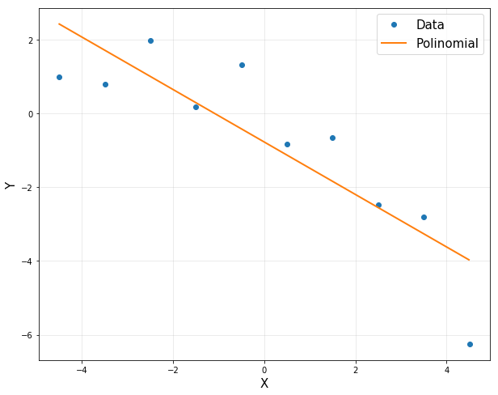

```python
xp = np.arange(-4.5, 4.5, 0.01)

plt.figure(figsize=(10, 8))
plt.plot(x, y, 'o', label = 'Data')
plt.plot(xp, np.polyval(p, xp), linewidth = 2, label = 'Polinomial')
plt.xlabel('X', fontsize = 15)
plt.ylabel('Y', fontsize = 15)
plt.legend(fontsize = 15)
plt.grid(alpha = 0.3)
plt.show()
```

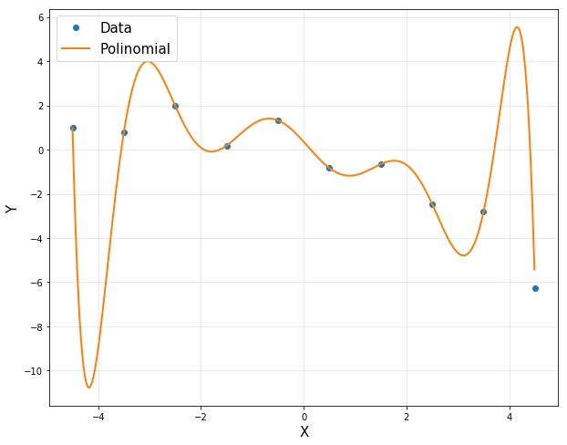

```python
p = np.polyfit(x, y, deg = 9)

xp = np.arange(-4.5, 4.5, 0.01)

plt.figure(figsize=(10, 8))
plt.plot(x, y, 'o', label = 'Data')
plt.plot(xp, np.polyval(p, xp), linewidth = 2, label = 'Polinomial')
plt.xlabel('X', fontsize = 15)
plt.ylabel('Y', fontsize = 15)
plt.legend(fontsize = 15)
plt.grid(alpha = 0.3)
plt.show()
```

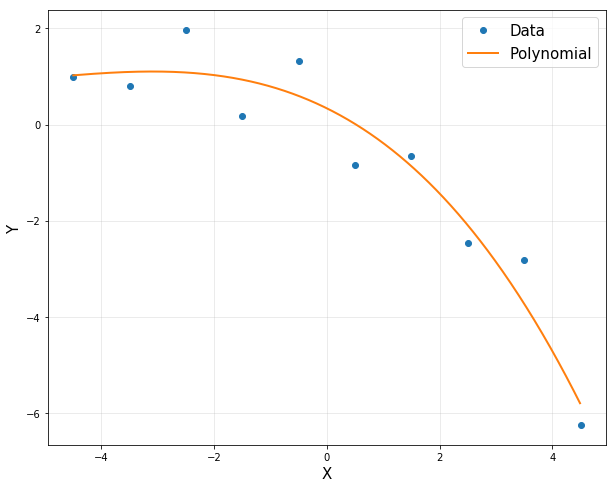

```python
p = np.polyfit(x, y, deg = 3)

xp = np.arange(-4.5, 4.5, 0.01)

plt.figure(figsize=(10, 8))
plt.plot(x, y, 'o', label = 'Data')
plt.plot(xp, np.polyval(p, xp), linewidth = 2, label = 'Polynomial')
plt.xlabel('X', fontsize = 15)
plt.ylabel('Y', fontsize = 15)
plt.legend(fontsize = 15)
plt.grid(alpha = 0.3)
plt.show()
```

# 2. Polynomial Regression in TensorFlow

- Construct explicit feature vectors
- Consider linear combinations of fixed nonlinear functions of the input variables, of the form

$$ \begin{bmatrix} 1 & x_{1} & x_1^2\\1 & x_{2} & x_2^2\\\vdots & \vdots\\1 & x_{m} & x_m^2 \end{bmatrix} \begin{bmatrix}\theta_0\\\theta_1 \\ \theta_2 \end{bmatrix} \quad \Rightarrow \quad \begin{bmatrix} \mid & \mid & \mid \\ b_0(x) & b_1(x) & b_2(x)\\ \mid & \mid & \mid \end{bmatrix} \begin{bmatrix}\theta_0\\\theta_1 \\ \theta_2 \end{bmatrix} $$

$$ \hat{y}=\sum_{i=0}^d{\theta_i b_i(x)} = \Phi \theta$$

- Polynomial functions

$$b_i(x) = x^i, \quad i = 0,\cdots,d$$

```python
from sklearn.preprocessing import MaxAbsScaler

# 10 data points
m = 10
train_x = np.linspace(-4.5, 4.5, 10).reshape(-1,1)
train_y = np.array([0.9819, 0.7973, 1.9737, 0.1838, 1.3180, -0.8361, -0.6591, -2.4701, -2.8122, -6.2512]).reshape(-1,1)

d = 9
train_X = np.hstack([train_x**(i+1) for i in range(d)])
train_X = MaxAbsScaler().fit_transform(train_X)
train_X = np.asmatrix(train_X)
```

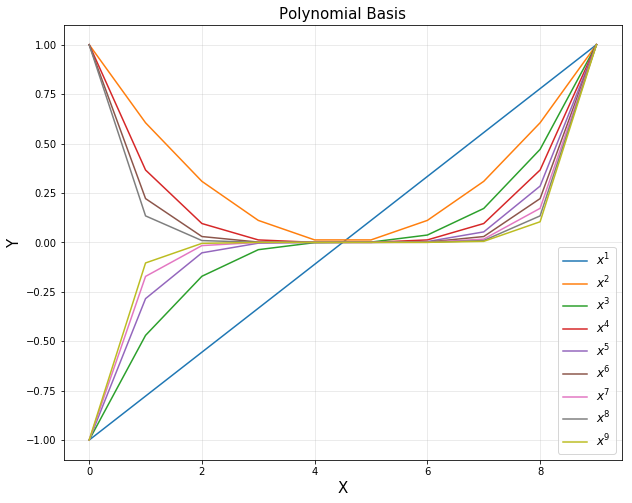

```python
plt.figure(figsize = (10,8))

for i in range(d):
    plt.plot(train_X[:,i], label = '$x^{}$'.format(i+1))

plt.title('Polynomial Basis', fontsize = 15)
plt.xlabel('X', fontsize = 15)
plt.ylabel('Y', fontsize = 15)
plt.grid(alpha = 0.3)
plt.legend(fontsize = 12)
plt.show()
```

```python
import tensorflow as tf

LR = 0.4
n_iter = 300000

x = tf.placeholder(tf.float32, [m, d])
y = tf.placeholder(tf.float32, [m, 1])

w = tf.Variable(tf.random_normal([d, 1]))
b = tf.Variable(tf.random_normal([1, 1]))

y_pred = tf.add(tf.matmul(x, w), b)
loss = tf.square(y_pred - y)
loss = tf.reduce_mean(loss)

optm = tf.train.AdamOptimizer(LR).minimize(loss)
init = tf.global_variables_initializer()

loss_record = []
with tf.Session() as sess:
    sess.run(init)
    for epoch in range(n_iter):
        sess.run(optm, feed_dict = {x: train_X, y: train_y})
        loss_record.append(sess.run(loss, feed_dict = {x: train_X, y: train_y}))

    w_val = sess.run(w)
    b_val = sess.run(b)
```

```python
xp = np.linspace(-4.5, 4.5, 100).reshape(-1,1)
Xp = np.hstack([xp**(i+1) for i in range(d)])
Xp = MaxAbsScaler().fit_transform(Xp)
Xp = np.asmatrix(Xp)
yp = Xp*w_val + b_val
```

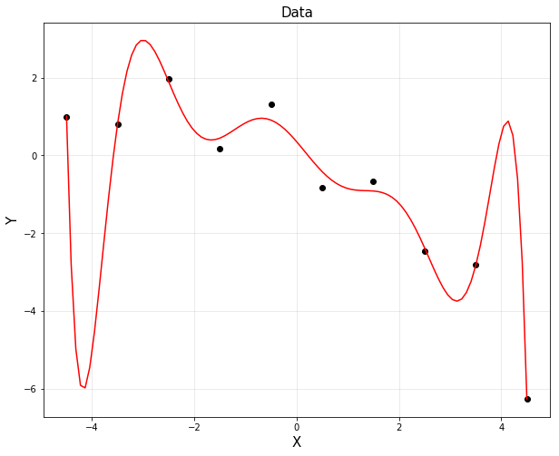

```python
plt.figure(figsize=(10,8))
plt.plot(train_x,train_y,'ko')
plt.plot(xp, yp, 'r')
plt.title('Data', fontsize = 15)
plt.xlabel('X', fontsize = 15)
plt.ylabel('Y', fontsize = 15)
#plt.axis('equal')
plt.grid(alpha = 0.3)
#plt.xlim([0, 5])
plt.show()
```

- Overfitting problem
  - Have you come across a situation where your model performed exceptionally well on train data, but was not able to predict test data ?
  - One of the most common problem data science professionals face is to avoid overfitting.
- Issue with rich representation
  - Low error on input data points, but high error nearby
  - Low error on training data, but high error on testing data

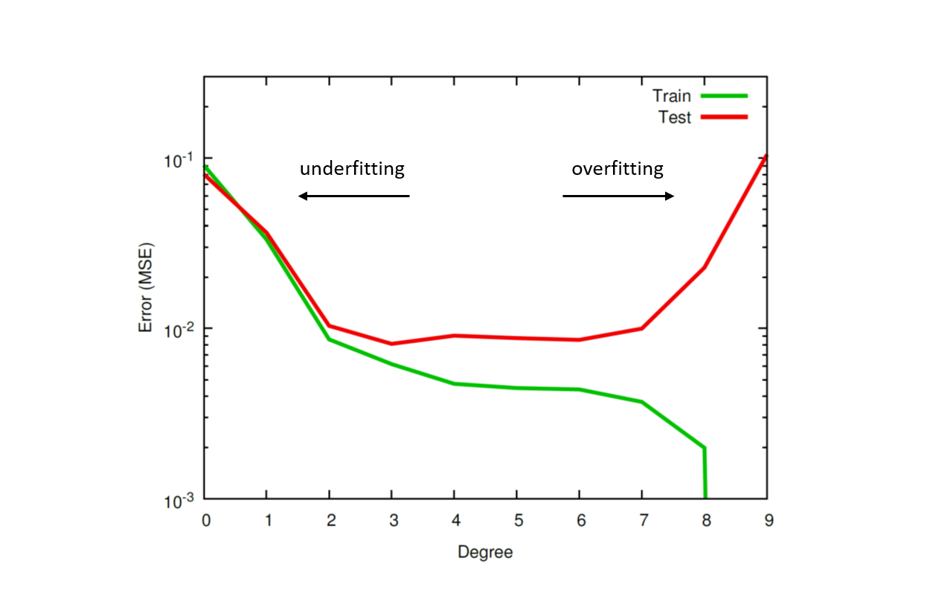

- Generalization Error
  - But what we really care about is loss of prediction on new data (𝑥,𝑦)
  - also called *generalization error*

# 3. Regularization to Reduce Overfitting

## 3.1. Regularization

With many features, prediction function becomes very expressive (model complexity)

- Choose less expressive function (e.g., lower degree polynomial, fewer RBF centers, larger RBF bandwidth)
- Keep the magnitude of the parameter small
- Regularization: penalize large parameters $\theta$
  $$\min\; \lVert \Phi \theta - y \rVert_2^2 + \lambda \lVert \theta \rVert_2^2$$
- $\lambda$: regularization parameter, trades off between low loss and small values of $\theta$

Often, overfitting associated with very large estimated parameters $\theta$

We want to balance

- how well function fits data
- magnitude of coefficients
  $$ \begin{align*} \text{Total cost } = \;&\underbrace{\text{measure of fit}}_{RSS(\theta)} + \;\lambda \cdot \underbrace{\text{measure of magnitude of coefficients}}_{\lambda \cdot \lVert \theta \rVert_2^2} \\ \\ \implies &\min\; \lVert \Phi \theta - y \rVert_2^2 + \lambda \lVert \theta \rVert_2^2 \end{align*} $$
  where $ RSS(\theta) = \lVert \Phi\theta - y \rVert^2_2 $, ( = Rresidual Sum of Squares) and $\lambda$ is a tuning parameter to be determined separately
- the second term, $\lambda \cdot \lVert \theta \rVert_2^2$, called a shrinkage penalty, is small when $\theta_1, \cdots,\theta_d$ are close to zeros, and so it has the effect of shrinking the estimates of $\theta_j$ towards zero
- The tuning parameter $\lambda$ serves to control the relative impact of these two terms on the regression coefficient estimates

```python
import tensorflow as tf

LR = 0.4
n_iter = 3000

x = tf.placeholder(tf.float32, [m, d])
y = tf.placeholder(tf.float32, [m, 1])

w = tf.Variable(tf.random_normal([d, 1]))
b = tf.Variable(tf.random_normal([1, 1]))

lamb = 0.1
y_pred = tf.add(tf.matmul(x, w), b)
loss = tf.reduce_mean(tf.square(y_pred - y))
reg = tf.reduce_mean(tf.square(w))
loss = tf.reduce_mean(loss + lamb*reg)

optm = tf.train.AdamOptimizer(LR).minimize(loss)
init = tf.global_variables_initializer()

loss_record = []
with tf.Session() as sess:
    sess.run(init)
    for epoch in range(n_iter):
        sess.run(optm, feed_dict = {x: train_X, y: train_y})
        loss_record.append(sess.run(loss, feed_dict = {x: train_X, y: train_y}))

    w_val = sess.run(w)
    b_val = sess.run(b)
```

```python
xp = np.linspace(-4.5, 4.5, 100).reshape(-1,1)
Xp = np.hstack([xp**(i+1) for i in range(d)])
Xp = MaxAbsScaler().fit_transform(Xp)
Xp = np.asmatrix(Xp)
yp = Xp*w_val + b_val
```

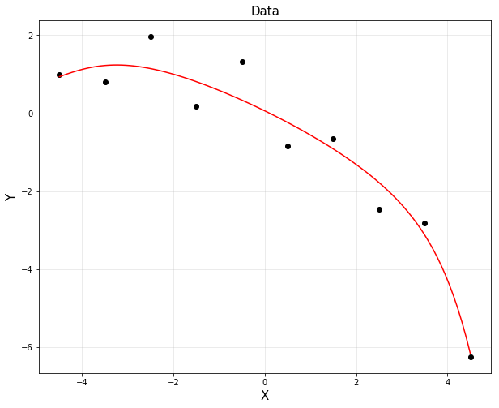

```python
plt.figure(figsize=(10,8))
plt.plot(train_x,train_y,'ko')
plt.plot(xp, yp, 'r')
plt.title('Data', fontsize = 15)
plt.xlabel('X', fontsize = 15)
plt.ylabel('Y', fontsize = 15)
#plt.axis('equal')
plt.grid(alpha = 0.3)
#plt.xlim([0, 5])
plt.show()
```

## 3.2. Different Regularization Techniques

- $L_2$ and $L_1$ regularizations
- Big Data
- Data augmentation
  - The simplest way to reduce overfitting is to increase the size of the training data

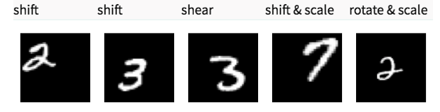

- Early stopping
  - When we see that the performance on the validation set is getting worse, we immediately stop the training on the model

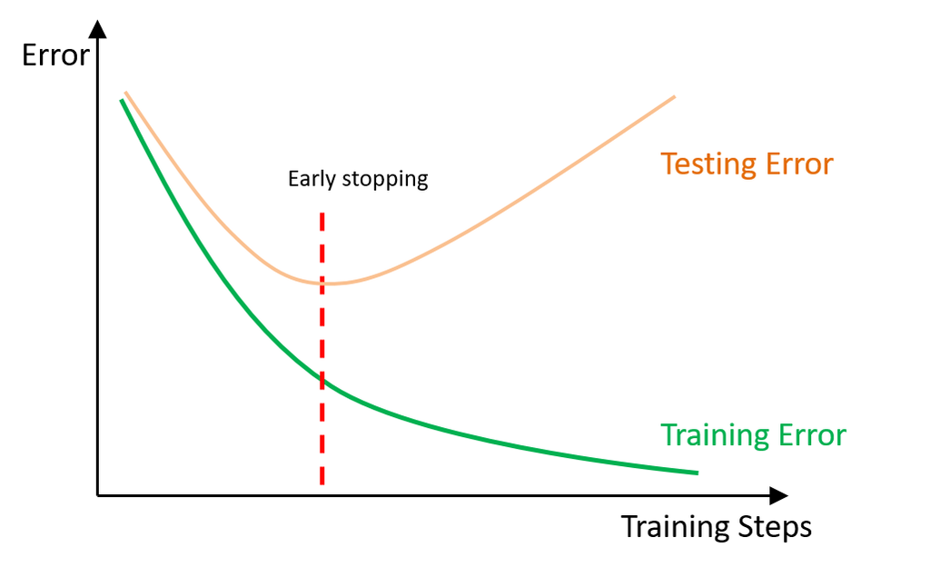

- Dropout (later)
  - This is the one of the most interesting types of regularization techniques.
  - It also produces very good results and is consequently the most frequently used regularization technique in the field of deep learning.
  - At every iteration, it randomly selects some nodes and removes them.
  - It can also be thought of as an ensemble technique in machine learning.

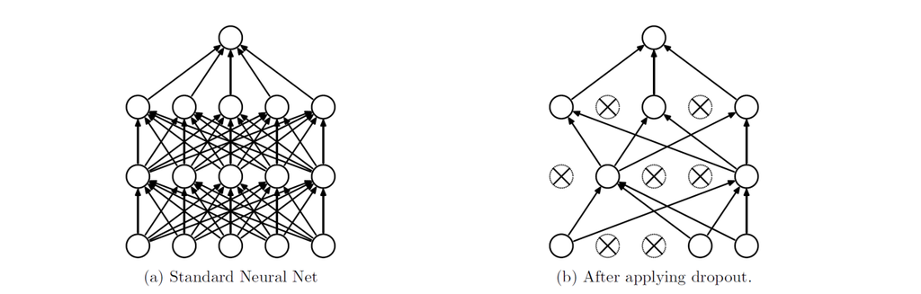

```python
%%javascript
$.getScript('https://kmahelona.github.io/ipython_notebook_goodies/ipython_notebook_toc.js')
```